# Homework 2: Sampling and Simulation

Intro to Data Science for Biology

Last updated November 01, 2018

```r
knitr::opts_chunk$set(echo = TRUE)
knitr::opts_chunk$set(eval = TRUE)
library(tidyverse)
```

## 1. R Warmup

**1a.** Create a vector of 100 randomly distributed numbers between 0 and 100 using `runif` and save the vector into the variable `my_vec`. If you cannot figure out runif, try `?runif`. What information does `str` and `summary` tell you about `my_vec`? How do they differ?

```r
my_vec <- runif(100, 0, 100)

str(my_vec)
```

```
##  num [1:100] 26.47 64.75 1.88 8.73 3.55 ...
```

```r
summary(my_vec)
```

```
##    Min. 1st Qu.  Median    Mean 3rd Qu.    Max.
##  0.3266 23.6696 46.9932 46.9108 68.1248 99.2718
```

```r
#str shows what information is in the vector and its length. summary
#gives information about the distribution of the data
```

**1b**. Try out a little plot. What does `hist(my_vec)` show you? What information does the helpfile for `hist` tell you about what you just did?

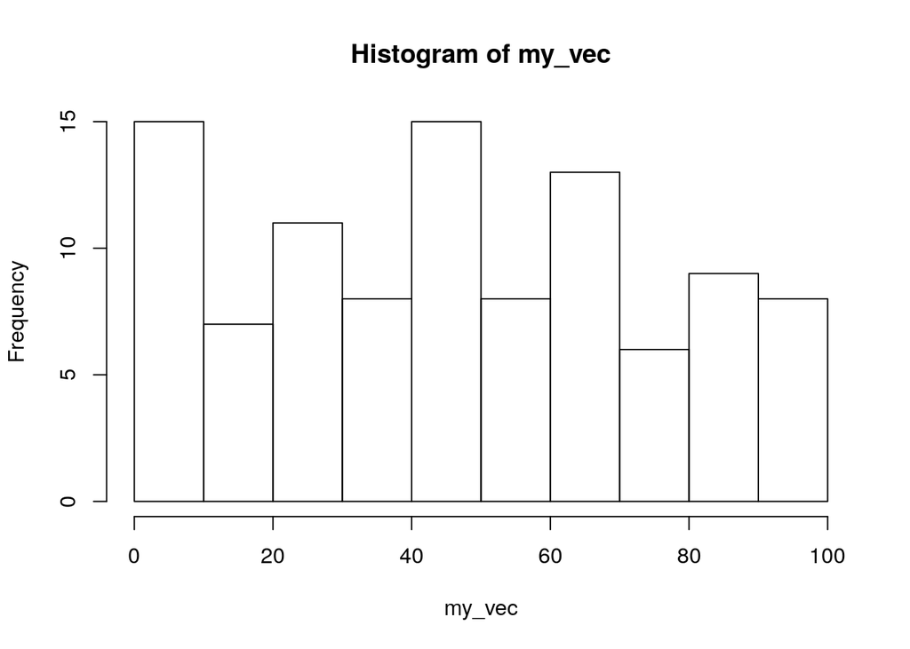

```r
hist(my_vec)
```

```r
#This is a histogram of my_vec
#showing frequently data occurs in a set of bins
```

**1c.** Load up the `mtcars` data set using `data(mtcars)`. Apply the following functions to mtcars: `class`, `str`, `summary`. What do these three functions tell you about mtcars?

```r
data(mtcars)
class(mtcars)
```

```
## [1] "data.frame"
```

```r
str(mtcars)
```

```
## 'data.frame':    32 obs. of  11 variables:
##  $ mpg : num  21 21 22.8 21.4 18.7 18.1 14.3 24.4 22.8 19.2 ...
##  $ cyl : num  6 6 4 6 8 6 8 4 4 6 ...
##  $ disp: num  160 160 108 258 360 ...
##  $ hp  : num  110 110 93 110 175 105 245 62 95 123 ...
##  $ drat: num  3.9 3.9 3.85 3.08 3.15 2.76 3.21 3.69 3.92 3.92 ...
##  $ wt  : num  2.62 2.88 2.32 3.21 3.44 ...
##  $ qsec: num  16.5 17 18.6 19.4 17 ...
##  $ vs  : num  0 0 1 1 0 1 0 1 1 1 ...
##  $ am  : num  1 1 1 0 0 0 0 0 0 0 ...
##  $ gear: num  4 4 4 3 3 3 3 4 4 4 ...
##  $ carb: num  4 4 1 1 2 1 4 2 2 4 ...
```

```r
summary(mtcars)
```

```
##       mpg             cyl             disp             hp
##  Min.   :10.40   Min.   :4.000   Min.   : 71.1   Min.   : 52.0
##  1st Qu.:15.43   1st Qu.:4.000   1st Qu.:120.8   1st Qu.: 96.5
##  Median :19.20   Median :6.000   Median :196.3   Median :123.0
##  Mean   :20.09   Mean   :6.188   Mean   :230.7   Mean   :146.7
##  3rd Qu.:22.80   3rd Qu.:8.000   3rd Qu.:326.0   3rd Qu.:180.0
##  Max.   :33.90   Max.   :8.000   Max.   :472.0   Max.   :335.0
##       drat             wt             qsec             vs
##  Min.   :2.760   Min.   :1.513   Min.   :14.50   Min.   :0.0000
##  1st Qu.:3.080   1st Qu.:2.581   1st Qu.:16.89   1st Qu.:0.0000
##  Median :3.695   Median :3.325   Median :17.71   Median :0.0000
##  Mean   :3.597   Mean   :3.217   Mean   :17.85   Mean   :0.4375
##  3rd Qu.:3.920   3rd Qu.:3.610   3rd Qu.:18.90   3rd Qu.:1.0000
##  Max.   :4.930   Max.   :5.424   Max.   :22.90   Max.   :1.0000
##        am              gear            carb
##  Min.   :0.0000   Min.   :3.000   Min.   :1.000
##  1st Qu.:0.0000   1st Qu.:3.000   1st Qu.:2.000
##  Median :0.0000   Median :4.000   Median :2.000
##  Mean   :0.4062   Mean   :3.688   Mean   :2.812
##  3rd Qu.:1.0000   3rd Qu.:4.000   3rd Qu.:4.000
##  Max.   :1.0000   Max.   :5.000   Max.   :8.000
```

```r
#mtcars is a data frame with 32 values in 11 columns. The values
#are numeric, and summary shows me how they are distributed
```

**1d** Look at the help file for the class `data.frame`. What does it tell you about these objects?

```r
#data.frames are both lists and matrices, and are fundamental to most of the modeling
#in R
```

## 2. Sample Properties

Consider the following vasopressin levels in voles.

```r
vole_vaso <- c(98,96,94,88,86,82,77,74,70,60,
           59,52,50,47,40,35,29,13,6,5)
```

**2a.** Say “Vole vasopressin” 10 times as fast as you can. How many times did you trip up?

**2b.** What is the mean, median, sd, and interquartile range of the sample?

**2c**. What is the standard error of the mean (do this with a formula!)?

**2d.** What does the standard error of the mean tell you about our estimate of the mean values of the population of vole vassopressin?

## 3. Sample Size for upper quartiles.

We can get the upper quartile value of vole vassopressin with

```r
quantile(vole_vaso, probs = 0.75)
```

```
## 75%
##  83
```

Let’s assume the sample is representative of the popultion.

**3a**. Use `sample()` to get just one resample with a sample size of 10. What is its upper quartile?

**3b.** Build an initial data frame for simulations with the sample sizes 5 through 20. Have 100 simulations per sample size.

```r
vole_sim <- data.frame(samp_size = rep(5:20, 100)) %>%
  mutate(sims = 1:n())
```

**3c.** Use this data frame to get simulated upper quartiles for each sample size.

```r
vole_sim <- vole_sim %>%
 # group_by(1:n()) %>%
 # group_by(1:sims) %>%
  rowwise() %>%
  mutate(uq = quantile(sample(vole_vaso, samp_size, replace=T), probs=0.75)) %>%
  ungroup()
```

**3d.** With a plot, make a guesstimate as to the best sample size for estimating the upper quartile of the population.

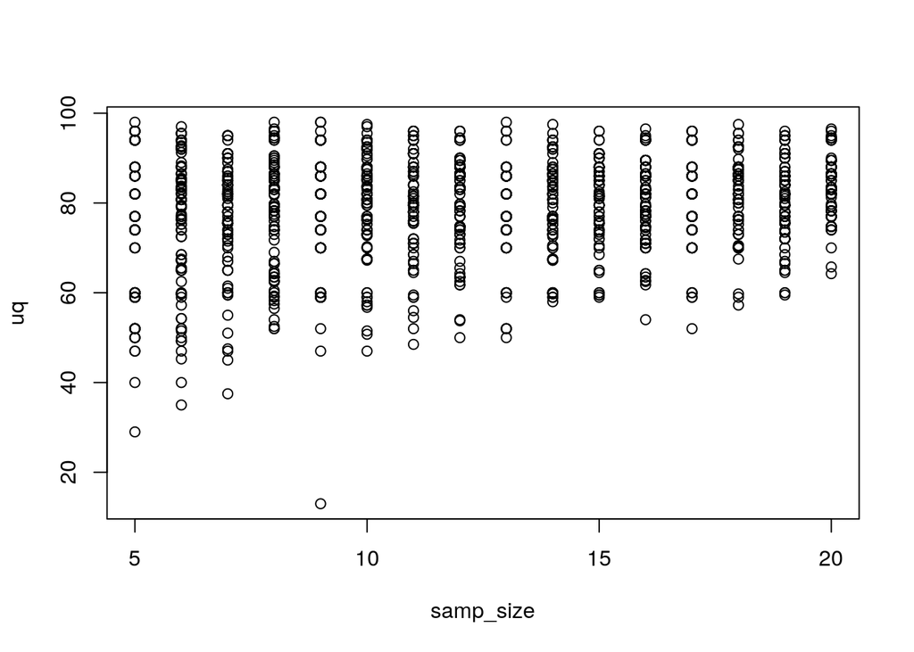

```r
plot(uq ~ samp_size, data=vole_sim)
```

## 4. SE and CI

**4a.** With the upper quartile simulations, calculate the SD for each sample size using `dplyr`

```r
vole_sim_summarize <- vole_sim %>%
  group_by(samp_size) %>%
  summarize(uq_se = sd(uq)) %>%
  ungroup()
```

**4b.** What does this value, the standard error of the upper quartile, mean?

**4c.** What is the CI of the upper quartile with a sample size of 10. What does this mean?

**4d.** Extra Credit: Instead of having each sim calculate a upper quartile, and then sifting down to the SE of that upper quartile (or the CI), have each simulation calculate a CI. Then, for just a sample size of 10, how many CI’s contain the true value of 83?